# Iteration Demo

## What are loops?

for loops are a programming tool for iteratively performing an operation, which may depend on the iteration number

Ex: Create a dataframe of 10 rows and 4 columns, where the ith column contains the first 10 multiples of i.

```r
my_df <- as.data.frame( matrix(0, nrow = 10, ncol = 4) )
for (i in 1:4){
  my_df[,i] <- (1:10)*i
}
```

Let’s rename the columns so they are of the form: multiples.i

```r
colnames(my_df) <- paste("multiples.",1:4, sep = "")
head(my_df)
```

|  | multiples.1 | multiples.2 | multiples.3 | multiples.4 |
| --- | --- | --- | --- | --- |
| 1 | 1 | 2 | 3 | 4 |
| 2 | 2 | 4 | 6 | 8 |
| 3 | 3 | 6 | 9 | 12 |
| 4 | 4 | 8 | 12 | 16 |
| 5 | 5 | 10 | 15 | 20 |
| 6 | 6 | 12 | 18 | 24 |

## map functions

map functions take a vector as input, and applies a specific function to each element of the vector, and returns a vector as output:

Let’s compute the means of each column of the matrix

```r
library(purrr)
map_dbl(my_df, mean)
```

```
## multiples.1 multiples.2 multiples.3 multiples.4
##         5.5        11.0        16.5        22.0
```

## Synthesis

Goal: Use cross-validation to determine the best k for knn

## Load Data

```r
GrinnellHousesClean <- read.csv("data/GrinnellHousesClean.csv")
```

Create an intial split

```r
library(rsample)
my_initial_split <- initial_split(GrinnellHousesClean)
Grinnell_train <- training(my_initial_split)
Grinnell_test <- testing(my_initial_split)
```

## Step 1

Build a template for a function to make a knn model

```r
library(kknn)

my_knn_mod <- kknn(SalePrice ~ Latitude + Longitude, train = Grinnell_train, test = Grinnell_test, k = 5, distance = 1, kernel = "rectangular")
```

## Step 2

Build a function which can take k as an input and return a knn model as output

```r
get_knn <- function(k){
  my_knn_mod <- kknn(SalePrice ~ Latitude + Longitude, train = Grinnell_train, test = Grinnell_test, k = k, distance = 1, kernel = "rectangular")
  my_knn_mod
}
```

```r
my_knn10 <- get_knn(10)
```

## Step 3

Build a function that will instead output the rmse for the knn model

```r
get_knn_rmse <- function(k){
  my_knn_mod <- kknn(SalePrice ~ Latitude + Longitude, train = Grinnell_train, test = Grinnell_test, k = k, distance = 1, kernel = "rectangular")
  my_preds <- my_knn_mod$fitted.values
  my_obs <- Grinnell_test$SalePrice
  my_rmse <- sqrt(mean((my_obs - my_preds)^2))
  my_rmse
}
```

```r
get_knn_rmse(10)
```

```
## [1] 54538.87
```

## Step 4

Use a for loop to compute test rmse for k between 1 and 30

```r
my_rmse <- numeric(30)
for (i in 1:30){
  my_rmse[i] <- get_knn_rmse(i)
}
```

```r
head(my_rmse)
```

```
## [1] 53573.16 47559.38 53368.88 54615.40 54576.33 54433.50
```

```r
library(dplyr)
```

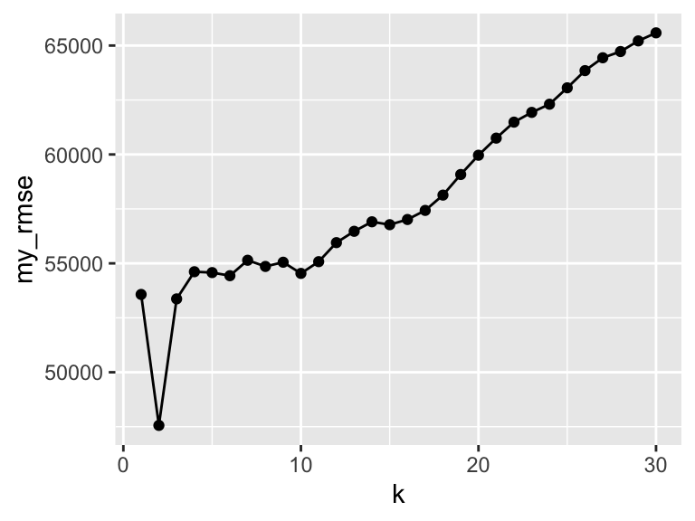

```r
library(ggplot2)
data.frame(k = 1:30, my_rmse) %>%
  ggplot(aes(x = k, y = my_rmse))+geom_line() + geom_point()
```

## Step 5

Use cross-validation to compare

```r
set.seed(331)
library(rsample)
my_cv <- vfold_cv(GrinnellHousesClean)
```

Let’s rebuild our `get_knn_rmse` function so that it takes a split as input:

```r
get_knn_rmse_split <- function(k, split){
  my_training <- analysis(split)
  my_testing <- assessment(split)
  my_knn_mod <- kknn(SalePrice ~ Latitude + Longitude, train = my_training, test = my_testing, k = k, distance = 1, kernel = "rectangular")
  my_preds <- my_knn_mod$fitted.values
  my_obs <- my_testing$SalePrice
  my_rmse <- sqrt(mean((my_obs - my_preds)^2))
  my_rmse
}
```

Now, use `map_dbl` to create a vector of rmse for each fold:

```r
library(purrr)
map_dbl(my_cv$splits, get_knn_rmse_split, k = 3)
```

```
##  [1] 45758.35 50363.51 54908.40 39963.55 52671.92 65881.48 50499.79 47328.87
##  [9] 57953.32 55120.20
```

Now, we use a for-loop to iterate across all k between 1 and 30:

```r
my_rmse_mat <- as.data.frame( matrix(NA, ncol = 30, nrow = 10))

for (i in 1:30){
  my_rmse_mat[,i] <- map_dbl(my_cv$splits, get_knn_rmse_split, k = i)
}
```

Now, we rename columns:

```r
colnames(my_rmse_mat) <- paste("knn",1:30, sep ="")
head(my_rmse_mat)
```

|  | knn1 | knn2 | knn3 | knn4 | knn5 | knn6 | knn7 | knn8 | knn9 | knn10 | knn11 | knn12 | knn13 | knn14 | knn15 | knn16 | knn17 | knn18 | knn19 | knn20 | knn21 | knn22 | knn23 | knn24 | knn25 | knn26 | knn27 | knn28 | knn29 | … |
| --- | --- | --- | --- | --- | --- | --- | --- | --- | --- | --- | --- | --- | --- | --- | --- | --- | --- | --- | --- | --- | --- | --- | --- | --- | --- | --- | --- | --- | --- | --- |
| 1 | 50349.83 | 39928.77 | 45758.35 | 47003.36 | 48582.56 | 48718.79 | 49081.25 | 49325.90 | 49176.13 | 49033.78 | 49086.92 | 49534.35 | 50296.06 | 50399.65 | 50740.69 | 50997.49 | 51174.02 | 51027.22 | 50855.35 | 50519.58 | 50220.69 | 50884.65 | 50654.51 | 51117.63 | 51310.07 | 51092.69 | 51543.61 | 51743.90 | 52111.62 | … |
| 2 | 64614.06 | 52242.03 | 50363.51 | 46303.75 | 44994.95 | 44155.28 | 43710.11 | 43903.48 | 44840.27 | 46460.05 | 45447.91 | 46264.33 | 46098.29 | 45749.37 | 46298.47 | 46066.31 | 46632.80 | 47059.58 | 48130.64 | 49277.54 | 50306.71 | 50493.60 | 50376.51 | 50597.05 | 51106.83 | 51207.99 | 51345.38 | 51608.59 | 51952.78 | … |
| 3 | 51115.68 | 55695.39 | 54908.40 | 53626.04 | 53565.85 | 52890.49 | 54862.35 | 53404.62 | 51279.81 | 49491.22 | 50239.92 | 51192.12 | 50641.21 | 50780.05 | 50206.62 | 50384.57 | 50582.70 | 51706.87 | 52439.20 | 52650.51 | 52510.59 | 52753.28 | 52836.38 | 52752.57 | 53059.40 | 53677.07 | 54100.56 | 54184.17 | 54974.16 | … |
| 4 | 47591.88 | 39746.78 | 39963.55 | 40788.41 | 39847.38 | 39793.58 | 39901.23 | 41969.95 | 44696.07 | 44769.89 | 45028.05 | 45213.67 | 45131.75 | 45132.07 | 45835.36 | 45603.10 | 46176.48 | 47357.66 | 50104.63 | 51535.31 | 53093.64 | 53638.67 | 54076.48 | 54674.38 | 54815.28 | 55461.67 | 55678.39 | 55405.72 | 55859.50 | … |
| 5 | 60970.21 | 52378.04 | 52671.92 | 51124.85 | 50665.40 | 50530.98 | 51326.63 | 50585.11 | 49411.26 | 49326.08 | 49159.39 | 49082.34 | 49477.70 | 48929.82 | 48792.87 | 48796.12 | 48635.18 | 49027.48 | 49167.14 | 49171.80 | 49191.12 | 49135.40 | 48991.96 | 49210.93 | 49051.10 | 48879.07 | 49115.17 | 49176.94 | 49231.60 | … |
| 6 | 72990.04 | 66727.98 | 65881.48 | 64410.72 | 69516.23 | 68872.83 | 68120.13 | 67279.06 | 68817.79 | 68788.31 | 68347.80 | 67844.52 | 67552.87 | 67228.85 | 66791.77 | 66238.00 | 66622.64 | 66904.18 | 67341.35 | 67557.02 | 67524.73 | 67377.53 | 67276.76 | 67327.39 | 67190.81 | 67071.19 | 67232.16 | 67202.08 | 67195.84 | … |

Finally, we can get our CV RMSE estimates by applying the `mean` function to each column using `map_dbl`

```r
cv_rmse <- map_dbl(my_rmse_mat, mean)
```

Finally, we plot to summarize:

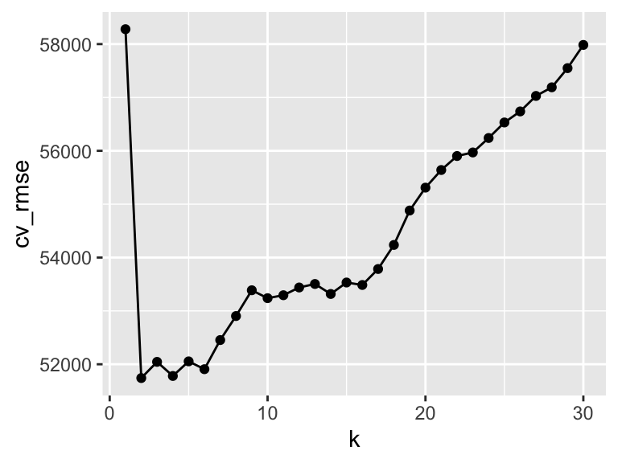

```r
data.frame(k = 1:30, cv_rmse) %>%
  ggplot(aes(x = k, y = cv_rmse))+geom_line() + geom_point()
```